# 1 KNN Theory + Iris_Demo

## K-Nearest Neighbors Algorithm using Scikit-Learn

The K-nearest neighbors (KNN) algorithm is a type of supervised machine learning algorithms. KNN is extremely easy to implement in its most basic form, and yet performs quite complex classification tasks.

> It is a lazy learning algorithm since it doesn't have a specialized training phase. Rather, it uses all of the data for training while classifying a new data point or instance.

KNN is a non-parametric learning algorithm, which means that it doesn't assume anything about the underlying data. This is an extremely useful feature since most of the real world data doesn't really follow any theoretical assumption e.g. linear-separability, uniform distribution, etc.

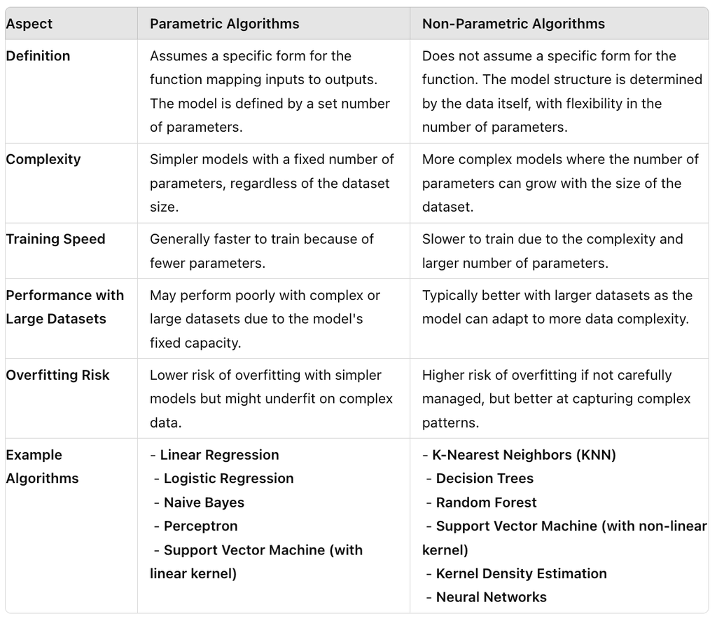

## Theory

The intuition behind the KNN algorithm is one of the simplest of all the supervised machine learning algorithms. It simply calculates the distance of a new data point to all other training data points. The distance can be of any type e.g Euclidean or Manhattan etc. It then selects the K-nearest data points, where K can be any integer. Finally it assigns the data point to the class to which the majority of the K data points belong.

Let's see this algorithm in action with the help of a simple example. Suppose you have a dataset with two variables, which when plotted, looks like the one in the following figure.

> Manhattan distance between 2 points is the distance along the axis, like you measure the distance in a right angled way. Usually used in circuits to measure the distance wires take; as the wires cannot run in between the circuit-boards.

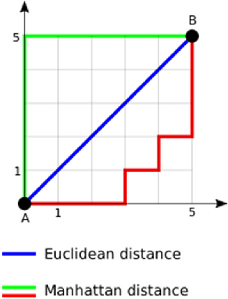

[figure not shown]

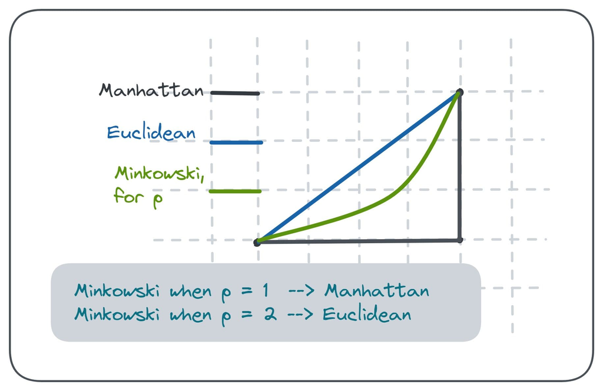

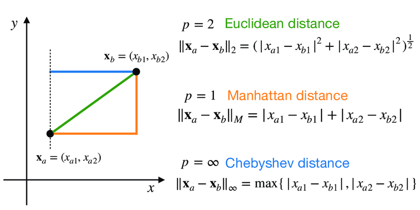

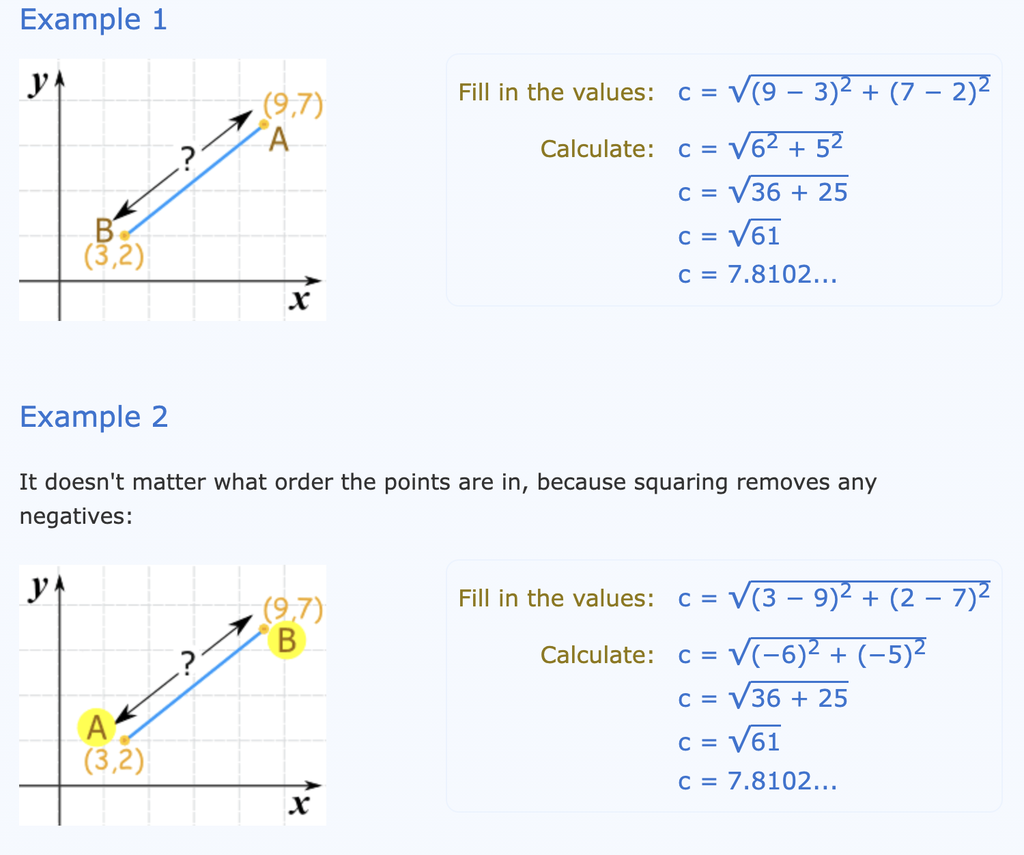

## Dataset

[output not shown]

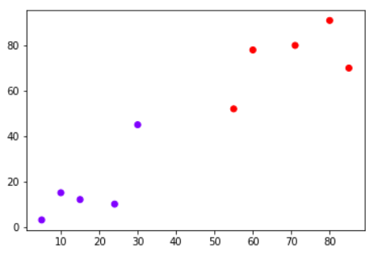

Your task is to classify a new data point 'X' into the 'Non-Defaulter' or 'LoanDefaulter' class. The coordinates of the data point are X1 = 45 and X2 = 50. Suppose the value of K is 3. The K-Nearest Neighbors (KNN) algorithm starts by calculating the distance from point X to all the existing points. It then identifies the 3 nearest points with the smallest distances to point X. These nearest points are highlighted in the figure below.

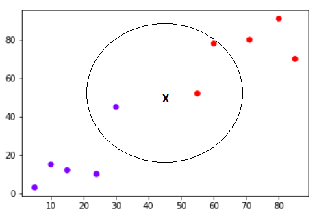

The final step of the KNN algorithm is to assign the new point to the class to which the majority of the three nearest points belong. From the figure above, we can see that two of the three nearest points belong to the class 'LoanDefaulter' while one belongs to the class 'Non-Defaulter'. Therefore, the new data point will be classified as 'LoanDefaulter'.

## Implementing KNN Algorithm with Scikit-Learn

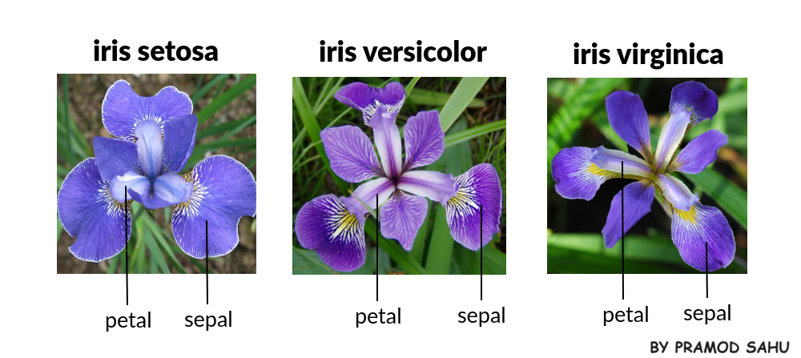

```python
# Necessary imports
import numpy as np
import pandas as pd
import matplotlib.pyplot as plt
import seaborn as sns

import warnings
warnings.filterwarnings('ignore')
```

```python
# import iris dataset from seaborn library
irisdata = sns.load_dataset('iris')
# print the first 5 rows of the dataset
irisdata.head()
```

|  | sepal_length | sepal_width | petal_length | petal_width | species |
| --- | --- | --- | --- | --- | --- |
| 0 | 5.1 | 3.5 | 1.4 | 0.2 | setosa |
| 1 | 4.9 | 3.0 | 1.4 | 0.2 | setosa |
| 2 | 4.7 | 3.2 | 1.3 | 0.2 | setosa |
| 3 | 4.6 | 3.1 | 1.5 | 0.2 | setosa |
| 4 | 5.0 | 3.6 | 1.4 | 0.2 | setosa |

```python
# Define features and target variable
X = irisdata.drop('species', axis=1)
y = irisdata['species']
```

```python
X.head()
```

|  | sepal_length | sepal_width | petal_length | petal_width |
| --- | --- | --- | --- | --- |
| 0 | 5.1 | 3.5 | 1.4 | 0.2 |
| 1 | 4.9 | 3.0 | 1.4 | 0.2 |
| 2 | 4.7 | 3.2 | 1.3 | 0.2 |
| 3 | 4.6 | 3.1 | 1.5 | 0.2 |
| 4 | 5.0 | 3.6 | 1.4 | 0.2 |

```python
y.head()
```

```
0    setosa
1    setosa
2    setosa
3    setosa
4    setosa
Name: species, dtype: object
```

```python
# Train-test split
from sklearn.model_selection import train_test_split
X_train, X_test, y_train, y_test = train_test_split(X, y,
                                                    test_size=0.25,
                                                    random_state=0)

# Print the shape of the training and testing data
print("Training data shape:", X_train.shape)
print("Testing data shape:", X_test.shape)
print("Training labels shape:", y_train.shape)
print("Testing labels shape:", y_test.shape)
```

```
Training data shape: (112, 4)
Testing data shape: (38, 4)
Training labels shape: (112,)
Testing labels shape: (38,)
```

```python
feature_names = X.columns
feature_names
```

```
Index(['sepal_length', 'sepal_width', 'petal_length', 'petal_width'], dtype='object')
```

```python
# Feature Scaling
# Before making any actual predictions, it is always
# a good practice to scale the features so that all of them
# can be uniformly evaluated.

from sklearn.preprocessing import StandardScaler
sc = StandardScaler()
X_train[feature_names] = sc.fit_transform(X_train[feature_names])
X_test[feature_names] = sc.transform(X_test[feature_names])
```

### KNN Hyperparameters

| Hyperparameter | Meaning / Purpose | Typical Values to Try in Industry |
| --- | --- | --- |
| **n_neighbors** | Number of nearest neighbors used to classify a new data point. Smaller values focus on local structure, larger values generalize more. | 3 – 15 (odd numbers like 3, 5, 7, 11 are common to avoid ties) |
| **weights** | How the influence of neighbors is calculated. • `'uniform'`: all neighbors have equal weight. • `'distance'`: closer neighbors have higher influence. | `'uniform'`, `'distance'` (both are often tested; `'distance'` sometimes gives better results in unevenly distributed data) |
| **algorithm** | The algorithm used to compute nearest neighbors. • `'auto'`: automatically chooses the best method. • `'ball_tree'`, `'kd_tree'`, `'brute'`: specific search algorithms for optimization. | `'auto'` (default and works well in most cases); `'kd_tree'` or `'ball_tree'` for large datasets with continuous variables |
| **leaf_size** | Affects the speed of tree-based neighbor searches (`ball_tree`, `kd_tree`). Larger sizes reduce tree depth but increase computation per node. | 20 – 50 (default is 30, and it's often fine-tuned when optimizing search performance) |
| **p** | Power parameter for the distance metric: • `p=1`: Manhattan distance • `p=2`: Euclidean distance. | 1 or 2 (Euclidean distance `p=2` is most common; Manhattan sometimes used in high-dimensional spaces) |
| **metric** | The distance metric to use when calculating neighbor distances. `'minkowski'` is a general case covering most distances. | `'minkowski'`, `'euclidean'`, `'manhattan'` (Euclidean is most common for continuous numeric data) |
| **metric_params** | Additional arguments for the distance metric. Typically left as `None`, unless using specialized metrics. | `None` (custom parameters are rare; standard metrics usually suffice) |
| **n_jobs** | Number of parallel jobs to run during neighbor search. • `None`: use a single core. • `-1`: use all available cores. | -1 (use all cores for speed during training and prediction on large datasets) |

```python
# Implementing KNN
# https://scikit-learn.org/stable/modules/generated/sklearn.neighbors.KNeighborsClassifier.html

# class sklearn.neighbors.KNeighborsClassifier(n_neighbors=5, *, weights='uniform', algorithm='auto', leaf_size=30, p=2, metric='minkowski', metric_params=None, n_jobs=None)

from sklearn.neighbors import KNeighborsClassifier
knn = KNeighborsClassifier(n_neighbors=5)
knn.fit(X_train, y_train)

# Predicting the labels for the training and testing data
y_pred_train = knn.predict(X_train)
y_pred_test = knn.predict(X_test)

# Evaluating the model
from sklearn.metrics import accuracy_score
print("Training accuracy:", accuracy_score(y_train, y_pred_train))
print("Testing accuracy:", accuracy_score(y_test, y_pred_test))
```

```
Training accuracy: 0.9642857142857143
Testing accuracy: 0.9736842105263158
```

```python
# list(zip(y_test, y_pred_test))
```

```python
# Number of misclassifications in the test set
misclassifications = np.sum(y_pred_test != y_test)
print("Number of misclassifications in the test set:", misclassifications)
```

```
Number of misclassifications in the test set: 1
```

```python
# The average number of misclassifications in the test set
misclassifications = np.mean(y_pred_test != y_test)
print("Average number of misclassifications in the test set:", misclassifications)
```

```
Average number of misclassifications in the test set: 0.02631578947368421
```

```python
1.0 - 0.02631578947368421
```

```
0.9736842105263158
```

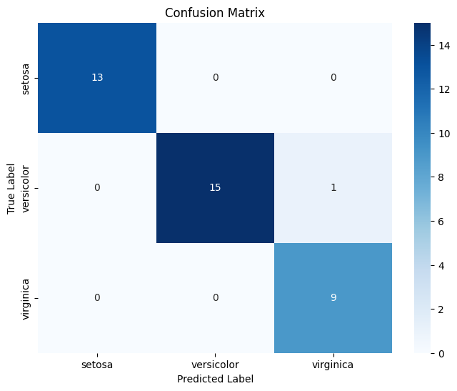

```python
# Evaluating the model
from sklearn.metrics import confusion_matrix
cm = confusion_matrix(y_test, y_pred_test)
cm_df = pd.DataFrame(cm, index=knn.classes_, columns=knn.classes_)
plt.figure(figsize=(8, 6))
sns.heatmap(cm_df, annot=True, fmt='d', cmap='Blues',
            xticklabels=knn.classes_, yticklabels=knn.classes_)
plt.title('Confusion Matrix')
plt.xlabel('Predicted Label')
plt.ylabel('True Label')
plt.show()
```

## **1. Precision**

**Meaning:** Out of all the predictions for a particular class, how many were actually correct?

**Formula:**

$$ \text{Precision} = \frac{\text{True Positives (TP)}}{\text{True Positives (TP)} + \text{False Positives (FP)}} $$

**Example:**

- For class **A**, predicted as A **10 times**.
- Actually correct **8 times** (True Positives), and wrong **2 times** (False Positives).

$$ \text{Precision for A} = \frac{8}{8 + 2} = 0.8 $$

## **2. Recall**

**Meaning:** Out of all actual instances of a class, how many were correctly predicted?

**Formula:**

$$ \text{Recall} = \frac{\text{True Positives (TP)}}{\text{True Positives (TP)} + \text{False Negatives (FN)}} $$

**Example:**

- For class **A**, total **12 actual A cases**.
- Correctly predicted as A **8 times**, missed **4 times** (False Negatives).

$$ \text{Recall for A} = \frac{8}{8 + 4} = 0.67 $$

## **3. F1-Score**

**Meaning:** Harmonic mean of Precision and Recall. Balances both in one score.

**Formula:**

$$ \text{F1-score} = 2 \times \frac{\text{Precision} \times \text{Recall}}{\text{Precision} + \text{Recall}} $$

**Example:** Using Precision = 0.8 and Recall = 0.67 from above,

$$ F1 = 2 \times \frac{0.8 \times 0.67}{0.8 + 0.67} \approx 0.73 $$

## **4. Support**

**Meaning:** The actual number of occurrences of the class in the dataset.

**Example:** If class **A** appeared **12 times**, its support is **12**.

## **5. Accuracy**

**Meaning:** Overall how many predictions were correct, across all classes.

**Formula:**

$$ \text{Accuracy} = \frac{\text{Total Correct Predictions}}{\text{Total Predictions}} $$

**Example:** If 90 predictions were made and 85 were correct,

$$ \text{Accuracy} = \frac{85}{90} \approx 0.94 $$

## **6. Macro Average**

**Meaning:** Average of Precision, Recall, or F1-score **calculated separately for each class**, then averaged. **Does not consider class imbalance.**

**Example:** If F1-scores for classes A, B, and C are 0.70, 0.80, and 0.90,

$$ \text{Macro Avg F1} = \frac{0.70 + 0.80 + 0.90}{3} = 0.80 $$

## **7. Weighted Average**

**Meaning:** Average of Precision, Recall, or F1-score for all classes, **weighted by the number of true instances (support) for each class.** This accounts for class imbalance.

**Example:** If F1-scores and supports are:

- A: F1=0.70, support=10
- B: F1=0.80, support=30
- C: F1=0.90, support=60

Weighted Avg F1 =

$$ \frac{(0.70 \times 10) + (0.80 \times 30) + (0.90 \times 60)}{10 + 30 + 60} = \frac{7 + 24 + 54}{100} = 0.85 $$

### Summary Table:

| Metric | Purpose | Formula Example |
| --- | --- | --- |
| Precision | Correct positive predictions / all positive predictions | TP / (TP + FP) |
| Recall | Correct positive predictions / actual positives | TP / (TP + FN) |
| F1-score | Harmonic mean of Precision and Recall | 2 × (P × R) / (P + R) |
| Support | Number of actual samples in the class | count of samples |
| Accuracy | Correct predictions / total predictions | (TP + TN) / total |
| Macro avg | Simple average across all classes | sum of metric / no. of classes |
| Weighted avg | Weighted by the number of samples in each class | sum of (metric × support) / total samples |

```python
# Evaluating the model
from sklearn.metrics import classification_report
print(classification_report(y_test, y_pred_test))
```

```
              precision    recall  f1-score   support

      setosa       1.00      1.00      1.00        13
  versicolor       1.00      0.94      0.97        16
   virginica       0.90      1.00      0.95         9

    accuracy                           0.97        38
   macro avg       0.97      0.98      0.97        38
weighted avg       0.98      0.97      0.97        38
```

### **Per Class Performance**

| Class | Precision | Recall | F1-score | Support |
| --- | --- | --- | --- | --- |
| **setosa** | 1.00 | 1.00 | 1.00 | 13 |
| **versicolor** | 1.00 | 0.94 | 0.97 | 16 |
| **virginica** | 0.90 | 1.00 | 0.95 | 9 |

**Interpretation:**

- **Setosa:** Perfect classification. All test samples were correctly classified as Setosa (Precision = Recall = F1 = 1.00).
- **Versicolor:** All predicted Versicolor were correct (Precision = 1.00), but 6% of actual Versicolor samples were misclassified (Recall = 0.94).
- **Virginica:** 90% Precision means some samples from other classes were incorrectly predicted as Virginica, but all actual Virginica samples were correctly identified (Recall = 1.00).

### **Overall Model Performance**

| Metric | Value |
| --- | --- |
| **Accuracy** | 0.97 |
| **Macro Avg F1-score** | 0.97 |
| **Weighted Avg F1-score** | 0.97 |

**Interpretation:**

- **Accuracy (97%)**: Out of all predictions, 97% were correct.
- **Macro average (0.97)**: The simple average across all classes, showing balanced performance.
- **Weighted average (0.97)**: Accounts for the number of samples in each class, confirming that the classifier is consistently accurate across imbalanced class sizes.

### **Summary of Results on Iris Dataset**

- The model performs **very well overall**, especially for Setosa and Virginica.
- Small misclassifications exist between **Versicolor and other classes**, which is common because Versicolor and Virginica sometimes have overlapping feature values.
- These are strong results for a simple KNN model, demonstrating that KNN works effectively on the well-behaved, clean Iris dataset.

## Comparing Error Rate with the K Value

One way to help you find the best value of K is to plot the graph of K value and the corresponding error rate for the dataset.

In this section, we will plot the mean error for the predicted values of test set for all the K values between 1 and 40.

To do so, let's first calculate the mean of error for all the predicted values where K ranges from 1 and 40. Execute the following script:

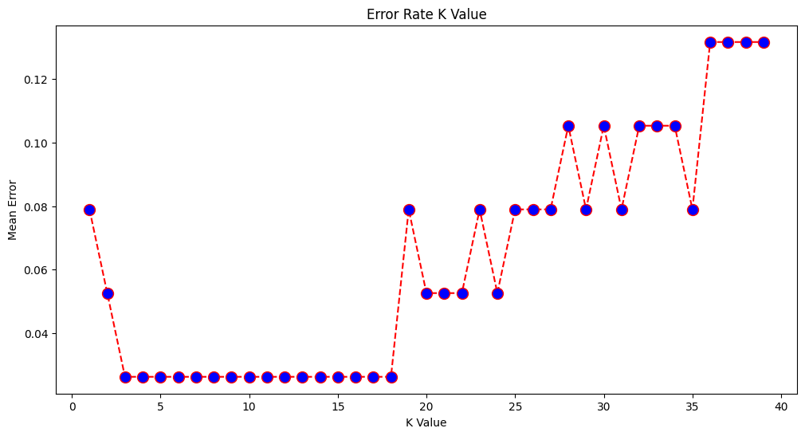

```python
error = [] # Initialize an empty list to store error values
# This list will be used to store the mean error for each K value

# Calculating error for K values between 1 and 40
for i in range(1, 40):
    knn = KNeighborsClassifier(n_neighbors=i)
    knn.fit(X_train, y_train)
    pred_i = knn.predict(X_test)
    error.append(np.mean(pred_i != y_test)) # Calculate the mean error for each K value
    #here != compares 2 ndarray objects
    # return value is array of true/false i.e 0/1 values , of which we are
    # finding the mean values.


    # The above script executes a loop from 1 to 40.
    # In each iteration the mean error for predicted values of test set
    # is calculated and the result is appended to the error list.

# The next step is to plot the error values against K values.
plt.figure(figsize=(12, 6))
plt.plot(range(1, 40), error, color='red', linestyle='dashed', marker='o',
         markerfacecolor='blue', markersize=10)
plt.title('Error Rate K Value')
plt.xlabel('K Value')
plt.ylabel('Mean Error')
plt.show()
```

### **Conclusion: Optimal K Selection**

- **Optimal K Range:** K values between **3 and 15** give the **lowest and most stable error rates** in your plot.
- A commonly chosen K is where the error first stabilizes at its lowest point:
  - **K = 5** or **K = 7** could be ideal starting points.
  - Choosing odd K values like 3, 5, or 7 is preferred to avoid ties in voting.
- **Avoid too small K (K=1):**
  - May cause the model to overfit (high variance).
- **Avoid too large K (>20):**
  - May cause the model to underfit (high bias).

### **Final Recommendation:**

Try **K = 5 or K = 7**, and possibly cross-validate within the 3 to 15 range to select the final K value.

**Pros:**

1. Simple and easy to implement.
2. Lazy learning algorithm that stores the training data and performs no upfront model training. New data can be added without retraining.
3. Requires tuning of only two hyperparameters: the number of neighbors (**K**) and the distance metric.

**Cons:**

1. Performs poorly on high-dimensional datasets due to the curse of dimensionality.
2. Computationally expensive during prediction, especially for large datasets, as distances to all training points must be computed.
3. Does not naturally handle categorical features, as distance metrics are designed for continuous data.